# Fortune 500 v.s. Non-fortune 500

Exploration of the different expectations for candidates between Fortune 500 U.S. companies and Non-Fortune 500 U.S. companies

### Minimum Requirement of Degree

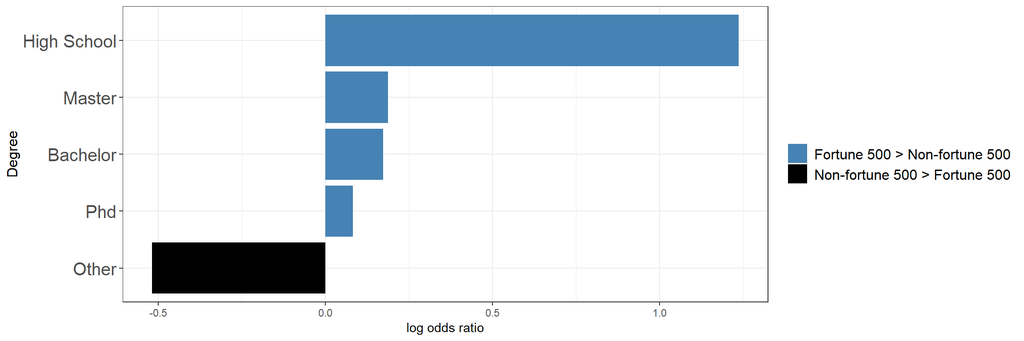

High school, master, bachelor, and Ph.D. degree are mentioned more frequently among fortune 500 companies than non-fortune 500 companies. “Other” refers to the category where a job post does not contain information about degree in its job descriptions, and job posts from non-fortune 500 companies fall more frequently in this category.

### Related Academic Background

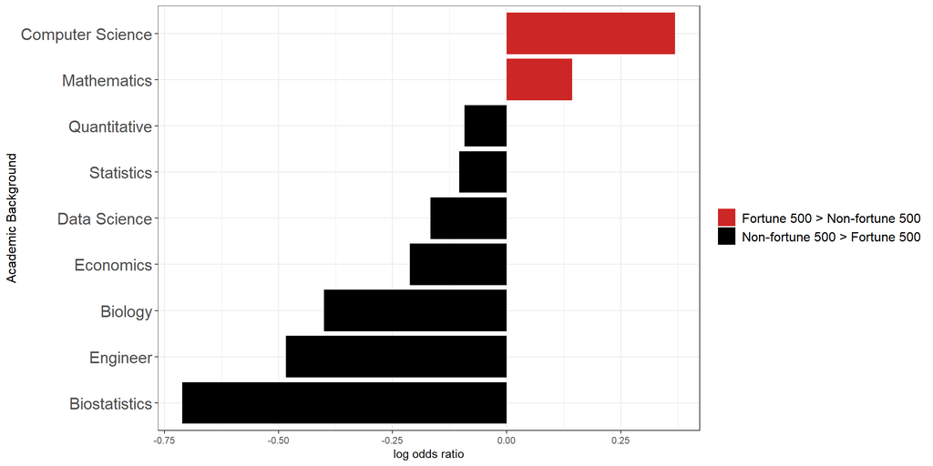

Non-fortune 500 companies mention Biostatistics, Engineer, Biology more frequently in their job posts, while candidates with background in Computer Science and Mathemetics are more preferable to fortune 500 companies.

### Programming / Statistical Tools

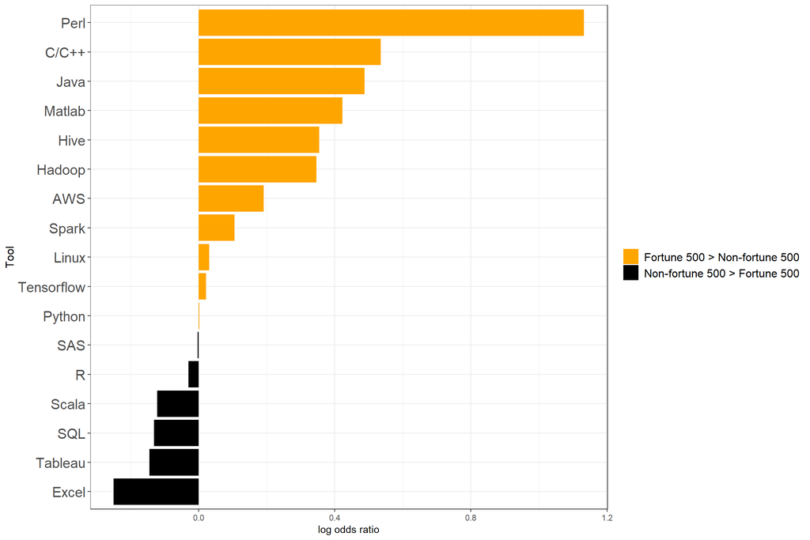

Excel, followed by Tableau and SQL are more required by non-fortune 500 companies, while fortune 500 companies are more likely to prefer candidates with high-level programming tool, such as Perl, C/C++, and Java.

### Rquired Skills

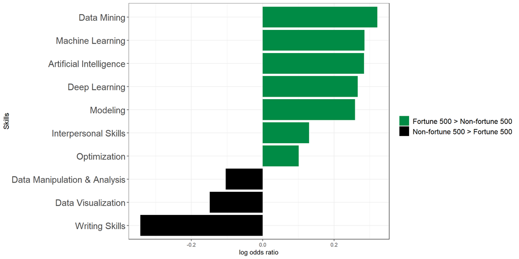

Writing skills, followed by data visualization, and data manipulation & analysis are more required by non-fortune 500 companies, while data mining, machine learning, artificial intelligence, deep learning, and modeling are more preferable to fortune 500 companies. It makes sense that non-fortune 500 companies just require general skills and elementary analytical skills, while fortune 500 companies desire their candidates to master much more advanced and professional data science skills.